# Appendix

Rohan Daryanani, Skye Liu, Michael Pascutoi, Katie Ryan, and Emma Wilson

2021-10-03

```r
load("~/2022 Notre Dame/Mod 1/Intro to Statistical Analysis/Case Studies/Corq Pain/CroqPain.rda")
load("~/2022 Notre Dame/Mod 1/Intro to Statistical Analysis/Case Studies/Corq Pain/CroqPain_new.rda")
```

## Appendix 1

The first fix that needed to be made to the data was getting rid of the repeat values.

```r
Fix1 <- CroqPain %>%
  arrange(STOR) %>%
  unique()
```

We then examined the distributions of each individual variable to see the shape of their distributions.

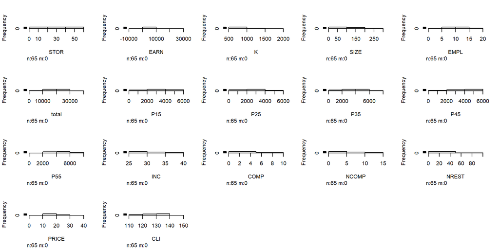

```r
hist.data.frame(CroqPain)
```

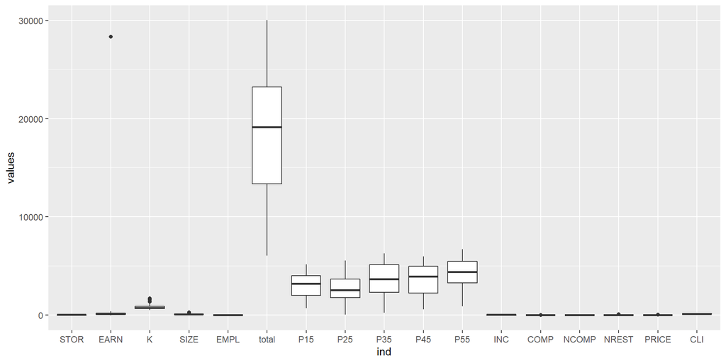

```r
ggplot(stack(Fix1), aes(x=ind, y = values))+
  geom_boxplot()
```

We noticed the very high outlier in EARN and decided to investigate further.

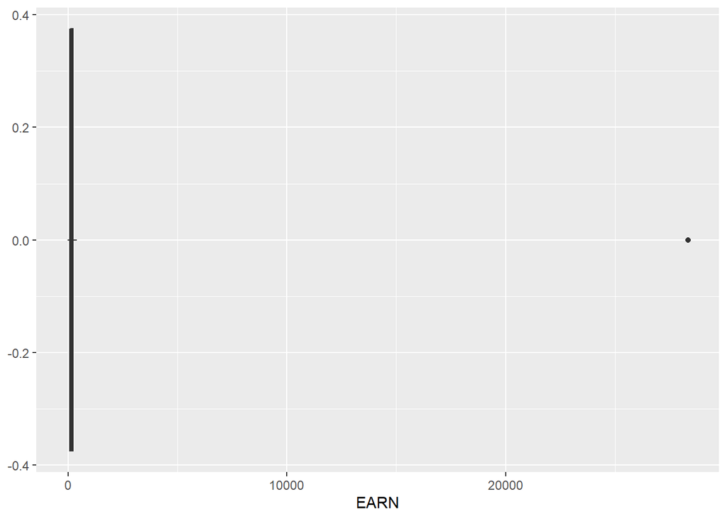

```r
ggplot(Fix1, aes(x = EARN)) +
  geom_boxplot()
```

This outlier was off by a factor of 1000 from the rest of the data. We realized that this earning variable is in $1000s so this data point may have not been scaled. This is consistent with the data table in the case, so we divided this point by 1000.

```r
Fix2 <- Fix1 %>%
  mutate(EARN = ifelse(STOR == 1, EARN/1000, EARN))
```

Looking at the distribution now, it is more normally distributed

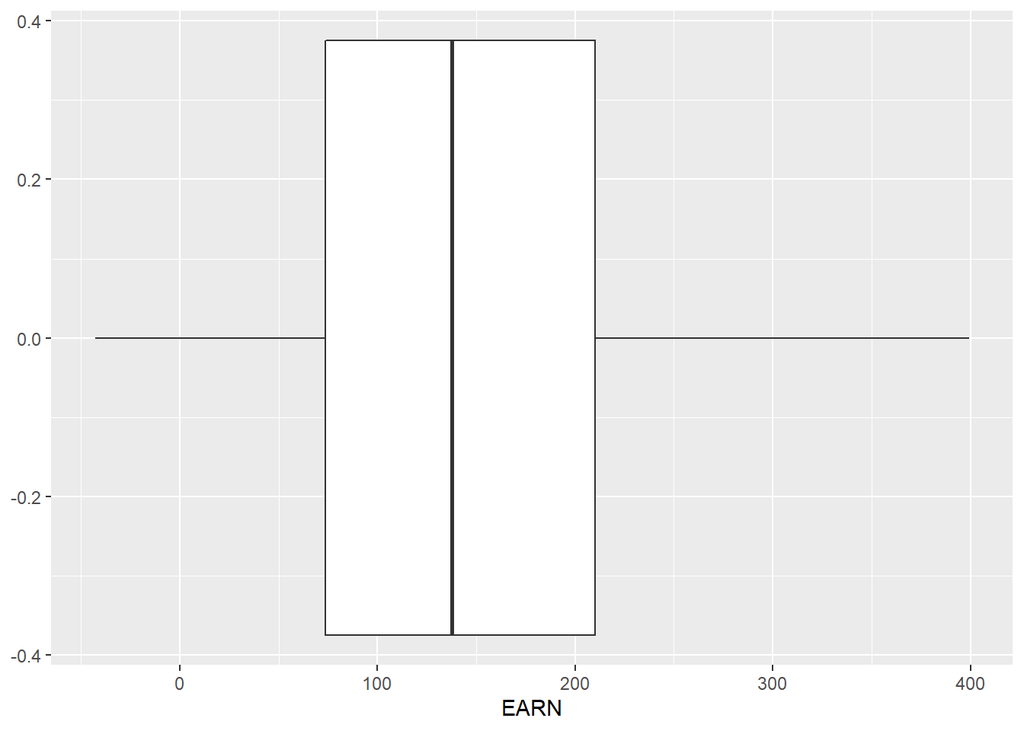

```r
ggplot(Fix2, aes(x = EARN)) +
  geom_boxplot()
```

We examined all other variables that contained outliers. None of the outliers seemed unreasonable to include in the data so no other changes were made.  
We did notice that looking at the sum of all the age breakdowns for population did not sum to the total population provided. This seemed logical since children under 15 were not accounted for in the groupings. However, we noticed that for Store 57 there was 40 people that were not accounted for in the total. We are assuming this small difference is due to a rounding error and will not be making any changes to the data regarding this discrepency.

```r
Fix2 %>%
  mutate(total2 = P15 + P25 + P35 + P45 + P55) %>%
  mutate(dif = total - total2) %>%
  select(total, total2, dif, P15, P25, P35, P45, P55) %>%
  tail(10)
```

```
## # A tibble: 10 x 8
##    total total2   dif   P15   P25   P35   P45   P55
##    <int>  <int> <int> <int> <int> <int> <int> <int>
##  1 17440  16870   570  2800  2350  3180  3050  5490
##  2 12880  11620  1260  2020  1780  2810  3000  2010
##  3 14310  12930  1380  2320  1040  2420  2770  4380
##  4 12990  11480  1510  2480  2380  2530  2670  1420
##  5 16380  14730  1650  1870  3290  2520  2660  4390
##  6 21360  20050  1310  3310  3590  3730  3970  5450
##  7 23400  23440   -40  3620  3820  5680  4260  6060
##  8 22830  21380  1450  4160  1230  5120  5200  5670
##  9 13510  12420  1090  1950  2360  2310  2320  3480
## 10 25490  24610   880  4890  1800  6070  5960  5890
```

We then saved the adjusted dataframe to an excel file to use in the rest of our analysis.

```r
write_xlsx(Fix2, "C:/Users/emmag/OneDrive/Documents/2022 Notre Dame/Mod 1/Intro to Statistical Analysis/Case Studies/Corq Pain/CroqPainFix.xlsx")
```

## Appendix 2

```r
CroqPainFix <- read_excel("C:/Users/emmag/OneDrive/Documents/2022 Notre Dame/Mod 1/Intro to Statistical Analysis/Case Studies/Corq Pain/CroqPainFix.xlsx")
```

### Appendix 2-1: Visualization

#### Appendix 2-1, A.1

Checking the distributions:

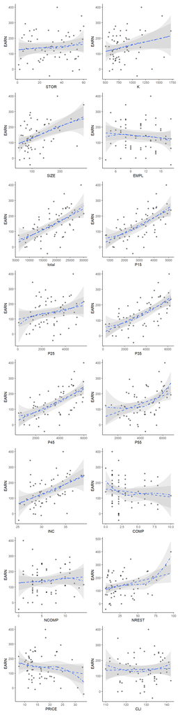

```r
visualize(
  CroqPainFix,
  xvar = c(
    "STOR", "K", "SIZE", "EMPL", "total", "P15", "P25", "P35",
    "P45", "P55", "INC", "COMP", "NCOMP", "NREST", "PRICE",
    "CLI"
  ),
  yvar = "EARN",
  type = "scatter",
  nrobs = -1,
  check = c("line", "loess"),
  theme = "theme_classic",
  custom = FALSE
)
```

Based on these scatterplots, most are linear but there are a few that may be polynomial.

#### Appendix 2-1, A.2

Looking at correlation:

```r
result <- correlation(
  CroqPainFix,
  vars = c(
    "STOR", "EARN", "K", "SIZE", "EMPL", "total", "P15", "P25",
    "P35", "P45", "P55", "INC", "COMP", "NCOMP", "NREST", "PRICE",
    "CLI"
  )
)
summary(result)
```

```
## Correlation
## Data        : CroqPainFix
## Method      : Pearson
## Variables   : STOR, EARN, K, SIZE, EMPL, total, P15, P25, P35, P45, P55, INC, COMP, NCOMP, NREST, PRICE, CLI
## Null hyp.   : variables x and y are not correlated
## Alt. hyp.   : variables x and y are correlated
##
## Correlation matrix:
##       STOR  EARN  K     SIZE  EMPL  total P15   P25   P35   P45   P55   INC
## EARN   0.11
## K     -0.08  0.24
## SIZE  -0.04  0.44  0.81
## EMPL  -0.21 -0.11  0.04  0.05
## total  0.14  0.59 -0.01 -0.02 -0.10
## P15    0.08  0.63 -0.07 -0.05 -0.10  0.96
## P25    0.07  0.23 -0.06 -0.08 -0.02  0.58  0.42
## P35    0.09  0.63 -0.05 -0.03 -0.12  0.96  0.98  0.43
## P45    0.08  0.63 -0.04 -0.02 -0.11  0.96  0.98  0.41  0.99
## P55    0.23  0.40  0.11  0.06 -0.09  0.77  0.68  0.29  0.67  0.65
## INC    0.04  0.46  0.21  0.18  0.09  0.11  0.15  0.02  0.14  0.14  0.01
## COMP  -0.15 -0.14 -0.28 -0.17  0.12 -0.14 -0.11 -0.01 -0.12 -0.13 -0.20 -0.08
## NCOMP  0.19  0.11 -0.11 -0.02  0.11  0.07  0.07  0.10  0.07  0.08  0.01  0.17
## NREST  0.08  0.34 -0.10 -0.10 -0.16  0.05  0.07  0.01  0.10  0.09 -0.02 -0.06
## PRICE -0.12 -0.18  0.60  0.07  0.08  0.04 -0.03  0.08 -0.01 -0.01  0.15  0.00
## CLI   -0.23  0.04  0.18  0.05  0.14  0.21  0.21  0.09  0.20  0.23  0.15  0.10
##       COMP  NCOMP NREST PRICE
## EARN
## K
## SIZE
## EMPL
## total
## P15
## P25
## P35
## P45
## P55
## INC
## COMP
## NCOMP  0.16
## NREST  0.11  0.01
```

[output cut: 23 more lines]

```
## K
## SIZE
## EMPL
## total
## P15
## P25
## P35
## P45
## P55
## INC
## COMP
## NCOMP
## NREST
## PRICE 0.63
## CLI   0.02  0.05
```

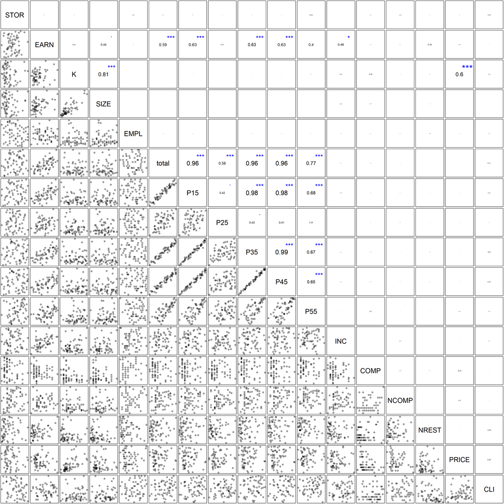

```r
plot(result, nrobs = 1000)
```

Looking at this correlation matrix, we see that certain variables are highly correlated.

#### Appendix 2-1, B.1

The total population and the different populations for age are highly correlated.

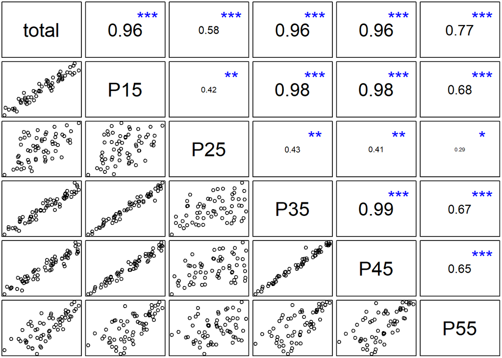

```r
result <- correlation(
  CroqPainFix,
  vars = c(
    "total", "P15", "P25", "P35", "P45", "P55")
  )
plot(result, nrobs = 1000)
```

Because of the high correlation, we know that all of these variables cannot be in the model together because it will have high multicollinearity.

#### Appendix 2-1, B.2

Additionally, we looked at the capital investment, price, and size variable that had strong correlations.

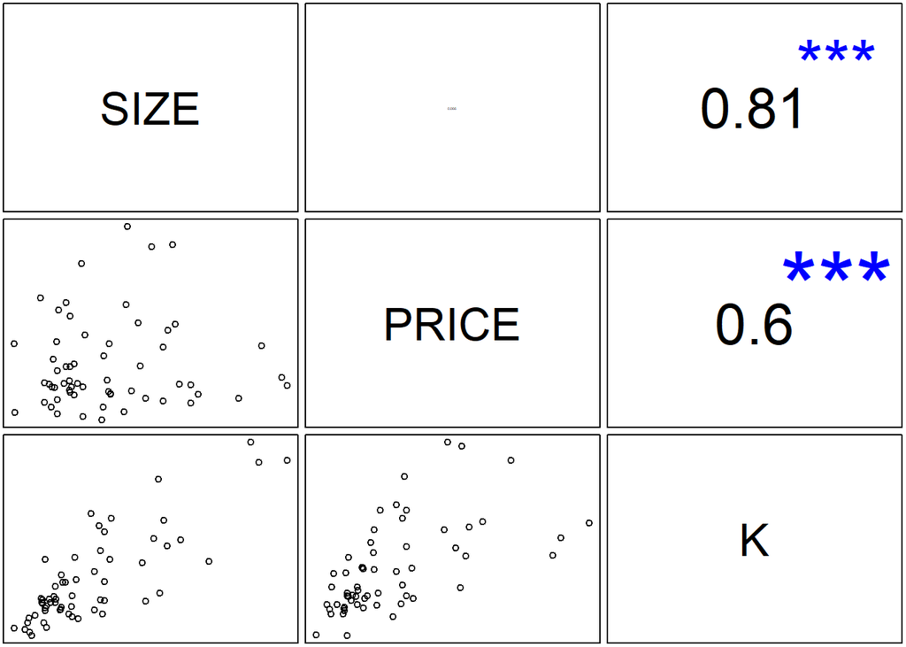

```r
result <- correlation(
  CroqPainFix,
  vars = c(
    "SIZE", "PRICE", "K")
  )
plot(result, nrobs = 1000)
```

These three variables will not be able to be in the model together because of high multicollinearity.

#### Appendix 2-1, C.1

We adjusted the data to account for the per capita proportions of several variables.

```r
CroqPainFix <- CroqPainFix %>%
  mutate(EARNpc = EARN/total,
         P15pc = P15/total,
         P25pc = P25/total,
         P35pc = P35/total,
         P45pc = P45/total,
         P55pc = P55/total,
         COMPpc = COMP/total,
         NCOMPpc = NCOMP/total,
         NRESTpc = NREST/total) %>%
  select(-total, -P15, -P25, -P35, -P45, -P55, -COMP, -NCOMP, -NREST)
```

#### Appendix 2-1, C.2

We reexamined the correlation matrix with the new variables.

```r
result <- correlation(
  CroqPainFix,
  vars = c(
    "STOR", "EARNpc", "K", "SIZE", "EMPL", "P15pc", "P25pc",
    "P35pc", "P45pc", "P55pc", "INC", "COMPpc", "NCOMPpc", "NRESTpc", "PRICE",
    "CLI"
  )
)
summary(result)
```

```
## Correlation
## Data        : CroqPainFix
## Method      : Pearson
## Variables   : STOR, EARNpc, K, SIZE, EMPL, P15pc, P25pc, P35pc, P45pc, P55pc, INC, COMPpc, NCOMPpc, NRESTpc, PRICE, CLI
## Null hyp.   : variables x and y are not correlated
## Alt. hyp.   : variables x and y are correlated
##
## Correlation matrix:
##         STOR  EARNpc K     SIZE  EMPL  P15pc P25pc P35pc P45pc P55pc INC
## EARNpc   0.10
## K       -0.08  0.23
## SIZE    -0.04  0.49   0.81
## EMPL    -0.21 -0.06   0.04  0.05
## P15pc   -0.06  0.24  -0.23 -0.17  0.01
## P25pc    0.03 -0.10  -0.02  0.01  0.04 -0.37
## P35pc    0.07  0.19  -0.13 -0.07 -0.10  0.81 -0.25
## P45pc    0.01  0.24  -0.12 -0.05 -0.04  0.83 -0.30  0.92
## P55pc    0.00 -0.14   0.16  0.07 -0.01 -0.60 -0.33 -0.72 -0.73
## INC      0.04  0.49   0.21  0.18  0.09  0.21 -0.04  0.16  0.17 -0.16
## COMPpc  -0.23 -0.03  -0.20 -0.09  0.19 -0.22  0.09 -0.45 -0.30  0.19 -0.16
## NCOMPpc  0.06  0.20  -0.02  0.09  0.16 -0.14  0.28 -0.30 -0.16  0.00  0.10
## NRESTpc -0.07  0.24  -0.15 -0.13 -0.05 -0.23 -0.19 -0.38 -0.27  0.40 -0.13
## PRICE   -0.12 -0.27   0.60  0.07  0.08 -0.17  0.02 -0.08 -0.11  0.13  0.00
## CLI     -0.23 -0.04   0.18  0.05  0.14  0.14 -0.03  0.17  0.23 -0.16  0.10
##         COMPpc NCOMPpc NRESTpc PRICE
## EARNpc
## K
## SIZE
## EMPL
## P15pc
## P25pc
## P35pc
## P45pc
## P55pc
## INC
## COMPpc
## NCOMPpc  0.44
## NRESTpc  0.50   0.16
## PRICE   -0.24  -0.19   -0.10
## CLI     -0.04  -0.04   -0.29    0.26
```

[output cut: 19 more lines]

```
## EARNpc
## K
## SIZE
## EMPL
## P15pc
## P25pc
## P35pc
## P45pc
## P55pc
## INC
## COMPpc
## NCOMPpc
## NRESTpc 0.21
## PRICE   0.14    0.44
## CLI     0.78    0.02    0.05
```

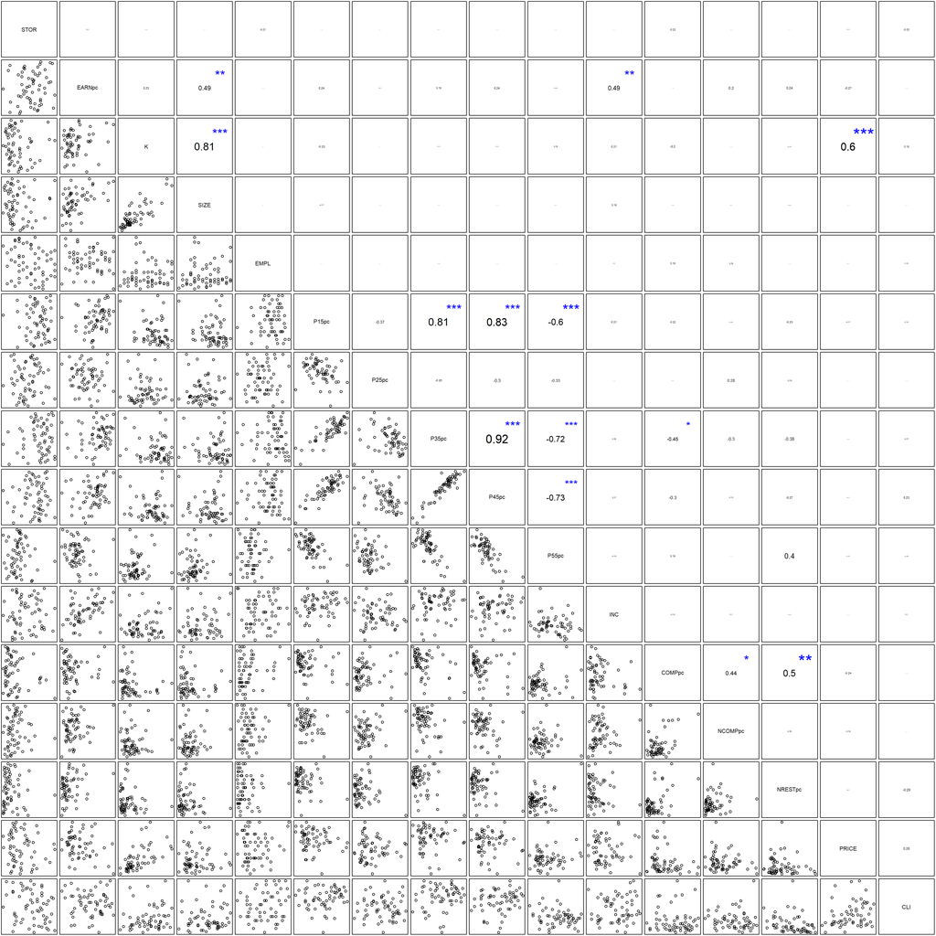

```r
plot(result, nrobs = 1000)
```

#### Appendix 2-1, C.3

With this change, we still see high correlation between the age group variables.

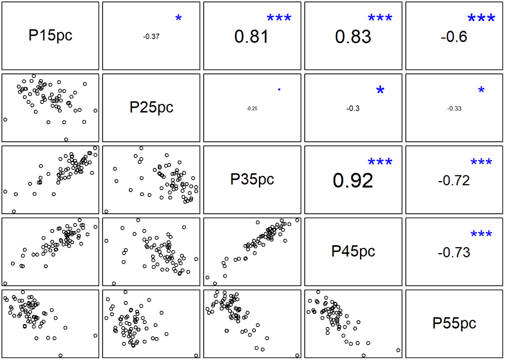

```r
result <- correlation(
  CroqPainFix,
  vars = c(
    "P15pc", "P25pc", "P35pc", "P45pc", "P55pc")
  )
plot(result, nrobs = 1000)
```

#### Appendix 2-1, D

We additionally added a variable for the performance ratio which is EARN/K.

```r
CroqPainFix <- CroqPainFix %>%
  mutate(PR = EARN/K)
```

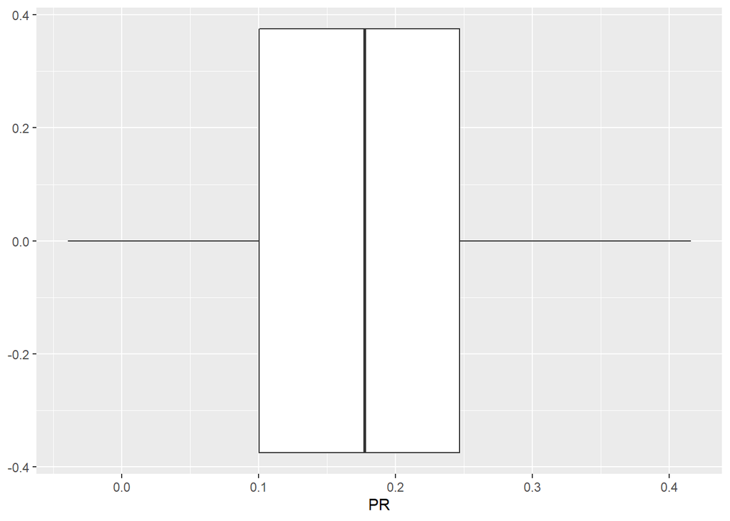

```r
ggplot(CroqPainFix, aes(x = PR)) +
  geom_boxplot()
```

Whis look approximately normal so we will proceed with this variable.

### Appendix 2-2

We took a top down approach to building the regression

#### Appendix 2-2, A

We first ran the model with all of the variables

```r
result <- regress(
  CroqPainFix,
  rvar = "EARNpc",
  evar = c(
    "K", "SIZE", "EMPL", "INC", "PRICE", "CLI", "P15pc", "P25pc",
    "P35pc", "P45pc", "P55pc", "COMPpc", "NCOMPpc", "NRESTpc"
  )
)
summary(result, sum_check = "vif")
```

```
## Linear regression (OLS)
## Data     : CroqPainFix
## Response variable    : EARNpc
## Explanatory variables: K, SIZE, EMPL, INC, PRICE, CLI, P15pc, P25pc, P35pc, P45pc, P55pc, COMPpc, NCOMPpc, NRESTpc
## Null hyp.: the effect of x on EARNpc is zero
## Alt. hyp.: the effect of x on EARNpc is not zero
##
##              coefficient std.error t.value p.value
##  (Intercept)      -0.028     0.011  -2.496   0.016 *
##  K                -0.000     0.000  -1.788   0.081 .
##  SIZE              0.000     0.000   3.396   0.001 **
##  EMPL             -0.000     0.000  -1.223   0.228
##  INC               0.001     0.000   4.797  < .001 ***
##  PRICE             0.000     0.000   0.750   0.457
##  CLI               0.000     0.000   1.146   0.258
##  P15pc             0.056     0.028   1.999   0.052 .
##  P25pc             0.006     0.012   0.482   0.632
##  P35pc             0.021     0.022   0.973   0.336
##  P45pc            -0.026     0.030  -0.853   0.398
##  P55pc            -0.002     0.012  -0.167   0.868
##  COMPpc           -3.891     2.209  -1.762   0.085 .
##  NCOMPpc           2.173     1.473   1.474   0.147
##  NRESTpc           1.396     0.242   5.760  < .001 ***
##
## Signif. codes:  0 '***' 0.001 '**' 0.01 '*' 0.05 '.' 0.1 ' ' 1
##
## R-squared: 0.766,  Adjusted R-squared: 0.693
## F-statistic: 10.506 df(14,45), p.value < .001
## Nr obs: 60
##
## Variance Inflation Factors
##            VIF   Rsq
## K       35.143 0.972
## SIZE    21.438 0.953
## P45pc   13.888 0.928
## PRICE   11.895 0.916
## P35pc   11.315 0.912
## P55pc    9.701 0.897
## P25pc    5.486 0.818
## P15pc    4.563 0.781
## COMPpc   2.217 0.549
## NRESTpc  1.967 0.492
## NCOMPpc  1.609 0.379
## INC      1.395 0.283
## CLI      1.358 0.264
## EMPL     1.272 0.214
```

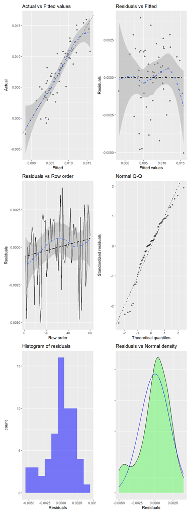

```r
plot(result, plots = "dashboard", lines = c("line", "loess"), custom = FALSE)
```

#### Appendix 2-2, C

We ran a employed stepwise to help determine some variables to omit.

```r
result <- regress(
  CroqPainFix,
  rvar = "EARNpc",
  evar = c(
    "K", "SIZE", "EMPL", "PRICE", "CLI", "P15pc", "P25pc",
    "P35pc", "P45pc", "P55pc", "COMPpc", "NCOMPpc", "NRESTpc"
  ),
  check = "stepwise-backward"
)
```

```
## Start:  AIC=-690.11
## EARNpc ~ K + SIZE + EMPL + PRICE + CLI + P15pc + P25pc + P35pc +
##     P45pc + P55pc + COMPpc + NCOMPpc + NRESTpc
##
##           Df  Sum of Sq        RSS     AIC
## - K        1 5.3000e-08 0.00038050 -692.10
## - P55pc    1 1.7500e-07 0.00038062 -692.08
## - EMPL     1 5.2900e-07 0.00038098 -692.03
## - P25pc    1 3.2910e-06 0.00038374 -691.59
## - PRICE    1 6.9180e-06 0.00038737 -691.03
## - P45pc    1 6.9260e-06 0.00038737 -691.03
## - P35pc    1 8.6950e-06 0.00038914 -690.75
## - CLI      1 1.1747e-05 0.00039220 -690.29
## <none>                  0.00038045 -690.11
## - SIZE     1 1.9789e-05 0.00040024 -689.07
## - NCOMPpc  1 2.6352e-05 0.00040680 -688.09
## - COMPpc   1 4.0630e-05 0.00042108 -686.02
## - P15pc    1 4.4223e-05 0.00042467 -685.51
## - NRESTpc  1 2.1416e-04 0.00059461 -665.32
##
## Step:  AIC=-692.1
## EARNpc ~ SIZE + EMPL + PRICE + CLI + P15pc + P25pc + P35pc +
##     P45pc + P55pc + COMPpc + NCOMPpc + NRESTpc
##
##           Df  Sum of Sq        RSS     AIC
## - P55pc    1 0.00000023 0.00038073 -694.07
## - EMPL     1 0.00000068 0.00038118 -694.00
## - P25pc    1 0.00000332 0.00038382 -693.58
## - P45pc    1 0.00000706 0.00038756 -693.00
## - P35pc    1 0.00000876 0.00038926 -692.74
## - CLI      1 0.00001191 0.00039242 -692.25
## <none>                  0.00038050 -692.10
## - NCOMPpc  1 0.00002679 0.00040729 -690.02
## - COMPpc   1 0.00004098 0.00042148 -687.97
## - P15pc    1 0.00004431 0.00042481 -687.49
## - PRICE    1 0.00004667 0.00042717 -687.16
## - NRESTpc  1 0.00021459 0.00059509 -667.27
## - SIZE     1 0.00036155 0.00074205 -654.03
##
## Step:  AIC=-694.07
```

[output cut: 62 more lines]

```
## - NRESTpc  1 0.00021356 0.00060525 -674.25
## - SIZE     1 0.00035969 0.00075138 -661.28
##
## Step:  AIC=-699.05
## EARNpc ~ SIZE + PRICE + P15pc + P25pc + COMPpc + NCOMPpc + NRESTpc
##
##           Df  Sum of Sq        RSS     AIC
## <none>                  0.00040035 -699.05
## - P25pc    1 0.00001797 0.00041832 -698.42
## - NCOMPpc  1 0.00001969 0.00042004 -698.17
## - PRICE    1 0.00004331 0.00044366 -694.89
## - COMPpc   1 0.00005279 0.00045314 -693.62
## - P15pc    1 0.00015050 0.00055085 -681.90
## - NRESTpc  1 0.00020778 0.00060814 -675.97
## - SIZE     1 0.00036281 0.00076316 -662.34
```

```r
summary(result, sum_check = "vif")
```

```
## ----------------------------------------------------
## Backward stepwise selection of variables
## ----------------------------------------------------
## Linear regression (OLS)
## Data     : CroqPainFix
## Response variable    : EARNpc
## Explanatory variables: K, SIZE, EMPL, PRICE, CLI, P15pc, P25pc, P35pc, P45pc, P55pc, COMPpc, NCOMPpc, NRESTpc
## Null hyp.: the effect of x on EARNpc is zero
## Alt. hyp.: the effect of x on EARNpc is not zero
##
##              coefficient std.error t.value p.value
##  (Intercept)      -0.013     0.004  -2.860   0.006 **
##  SIZE              0.000     0.000   6.865  < .001 ***
##  PRICE            -0.000     0.000  -2.372   0.021 *
##  P15pc             0.083     0.019   4.421  < .001 ***
##  P25pc             0.011     0.007   1.528   0.133
##  COMPpc           -5.965     2.278  -2.618   0.012 *
##  NCOMPpc           2.581     1.614   1.599   0.116
##  NRESTpc           1.341     0.258   5.195  < .001 ***
##
## Signif. codes:  0 '***' 0.001 '**' 0.01 '*' 0.05 '.' 0.1 ' ' 1
##
## R-squared: 0.627,  Adjusted R-squared: 0.577
## F-statistic: 12.509 df(7,52), p.value < .001
## Nr obs: 60
##
## Variance Inflation Factors
##     COMPpc NRESTpc P15pc P25pc NCOMPpc PRICE  SIZE
## VIF  1.713   1.622 1.477 1.473   1.403 1.134 1.116
## Rsq  0.416   0.383 0.323 0.321   0.287 0.118 0.104
```

#### Appendix 2-2, C

```r
result <- regress(
  CroqPainFix,
  rvar = "EARNpc",
  evar = c(
    "SIZE", "EMPL", "INC", "K", "CLI", "P15pc", "P25pc",
    "P35pc", "P45pc", "P55pc", "COMPpc", "NCOMPpc", "NRESTpc"
  )
)
summary(result, sum_check = "vif")
```

```
## Linear regression (OLS)
## Data     : CroqPainFix
## Response variable    : EARNpc
## Explanatory variables: SIZE, EMPL, INC, K, CLI, P15pc, P25pc, P35pc, P45pc, P55pc, COMPpc, NCOMPpc, NRESTpc
## Null hyp.: the effect of x on EARNpc is zero
## Alt. hyp.: the effect of x on EARNpc is not zero
##
##              coefficient std.error t.value p.value
##  (Intercept)      -0.028     0.011  -2.601   0.012 *
##  SIZE              0.000     0.000   6.844  < .001 ***
##  EMPL             -0.000     0.000  -1.032   0.307
##  INC               0.001     0.000   4.890  < .001 ***
##  K                -0.000     0.000  -3.304   0.002 **
##  CLI               0.000     0.000   1.196   0.238
##  P15pc             0.056     0.028   2.024   0.049 *
##  P25pc             0.008     0.011   0.725   0.472
##  P35pc             0.024     0.022   1.127   0.266
##  P45pc            -0.025     0.030  -0.818   0.418
##  P55pc            -0.000     0.012  -0.021   0.983
##  COMPpc           -4.045     2.189  -1.848   0.071 .
##  NCOMPpc           2.098     1.463   1.434   0.158
##  NRESTpc           1.415     0.240   5.903  < .001 ***
##
## Signif. codes:  0 '***' 0.001 '**' 0.01 '*' 0.05 '.' 0.1 ' ' 1
##
## R-squared: 0.763,  Adjusted R-squared: 0.696
## F-statistic: 11.38 df(13,46), p.value < .001
## Nr obs: 60
##
## Variance Inflation Factors
##            VIF   Rsq
## P45pc   13.849 0.928
## P35pc   10.968 0.909
## P55pc    9.328 0.893
## P25pc    5.053 0.802
## P15pc    4.562 0.781
## K        3.787 0.736
## SIZE     3.388 0.705
## COMPpc   2.197 0.545
## NRESTpc  1.944 0.486
## NCOMPpc  1.602 0.376
## CLI      1.354 0.261
## INC      1.202 0.168
## EMPL     1.121 0.108
```

This reduced the multicollinearity.

#### Appendix 2-2, D

```r
result <- regress(
  CroqPainFix,
  rvar = "EARNpc",
  evar = c(
    "K", "PRICE", "EMPL", "INC", "CLI", "P35pc", "COMPpc",
    "NCOMPpc", "NRESTpc"
  )
)
summary(result, sum_check = "vif")
```

```
## Linear regression (OLS)
## Data     : CroqPainFix
## Response variable    : EARNpc
## Explanatory variables: K, PRICE, EMPL, INC, CLI, P35pc, COMPpc, NCOMPpc, NRESTpc
## Null hyp.: the effect of x on EARNpc is zero
## Alt. hyp.: the effect of x on EARNpc is not zero
##
##              coefficient std.error t.value p.value
##  (Intercept)      -0.019     0.006  -2.887   0.006 **
##  K                 0.000     0.000   5.355  < .001 ***
##  PRICE            -0.000     0.000  -5.066  < .001 ***
##  EMPL             -0.000     0.000  -0.126   0.900
##  INC               0.000     0.000   3.844  < .001 ***
##  CLI               0.000     0.000   0.606   0.547
##  P35pc             0.030     0.009   3.307   0.002 **
##  COMPpc           -3.693     2.371  -1.557   0.126
##  NCOMPpc           2.789     1.519   1.836   0.072 .
##  NRESTpc           1.248     0.244   5.118  < .001 ***
##
## Signif. codes:  0 '***' 0.001 '**' 0.01 '*' 0.05 '.' 0.1 ' ' 1
##
## R-squared: 0.675,  Adjusted R-squared: 0.617
## F-statistic: 11.55 df(9,50), p.value < .001
## Nr obs: 60
##
## Variance Inflation Factors
##           VIF   Rsq
## COMPpc  2.048 0.512
## PRICE   1.827 0.453
## K       1.762 0.433
## NRESTpc 1.597 0.374
## P35pc   1.529 0.346
## NCOMPpc 1.370 0.270
## CLI     1.262 0.208
## INC     1.178 0.151
## EMPL    1.119 0.106
```

#### Appendix 2-2, E

We ran another stepwise with this reduced set of variables.

```r
result <- regress(
  CroqPainFix,
  rvar = "EARNpc",
  evar = c(
    "K", "SIZE", "EMPL", "INC", "PRICE", "CLI", "P35pc", "COMPpc",
    "NCOMPpc", "NRESTpc"
  ),
  check = "stepwise-backward"
)
```

```
## Start:  AIC=-714.76
## EARNpc ~ K + SIZE + EMPL + INC + PRICE + CLI + P35pc + COMPpc +
##     NCOMPpc + NRESTpc
##
##           Df  Sum of Sq        RSS     AIC
## - CLI      1 4.2020e-06 0.00028300 -715.86
## - PRICE    1 4.2940e-06 0.00028309 -715.85
## - EMPL     1 7.3130e-06 0.00028611 -715.21
## <none>                  0.00027880 -714.76
## - COMPpc   1 1.2365e-05 0.00029116 -714.16
## - NCOMPpc  1 1.8546e-05 0.00029734 -712.90
## - K        1 2.2983e-05 0.00030178 -712.01
## - P35pc    1 5.0825e-05 0.00032962 -706.71
## - SIZE     1 7.0172e-05 0.00034897 -703.29
## - INC      1 1.5568e-04 0.00043447 -690.14
## - NRESTpc  1 1.8533e-04 0.00046412 -686.18
##
## Step:  AIC=-715.86
## EARNpc ~ K + SIZE + EMPL + INC + PRICE + P35pc + COMPpc + NCOMPpc +
##     NRESTpc
##
##           Df  Sum of Sq        RSS     AIC
## - PRICE    1 4.7190e-06 0.00028772 -716.87
## - EMPL     1 6.4950e-06 0.00028949 -716.50
## <none>                  0.00028300 -715.86
## - COMPpc   1 9.9460e-06 0.00029294 -715.79
## - NCOMPpc  1 1.8425e-05 0.00030142 -714.08
## - K        1 2.1915e-05 0.00030491 -713.39
## - P35pc    1 5.8393e-05 0.00034139 -706.61
## - SIZE     1 6.8530e-05 0.00035153 -704.85
## - INC      1 1.5810e-04 0.00044110 -691.24
## - NRESTpc  1 1.8431e-04 0.00046731 -687.77
##
## Step:  AIC=-716.87
## EARNpc ~ K + SIZE + EMPL + INC + P35pc + COMPpc + NCOMPpc + NRESTpc
##
##           Df  Sum of Sq        RSS     AIC
## - EMPL     1 3.8800e-06 0.00029160 -718.07
## <none>                  0.00028772 -716.87
## - COMPpc   1 1.2108e-05 0.00029982 -716.40
## - NCOMPpc  1 1.8315e-05 0.00030603 -715.17
## - P35pc    1 6.3573e-05 0.00035129 -706.89
## - K        1 6.3602e-05 0.00035132 -706.89
## - INC      1 1.6172e-04 0.00044943 -692.11
## - NRESTpc  1 1.8589e-04 0.00047361 -688.97
## - SIZE     1 2.4282e-04 0.00053054 -682.16
##
## Step:  AIC=-718.07
## EARNpc ~ K + SIZE + INC + P35pc + COMPpc + NCOMPpc + NRESTpc
##
##           Df  Sum of Sq        RSS     AIC
## <none>                  0.00029160 -718.07
## - COMPpc   1 1.5774e-05 0.00030737 -716.91
## - NCOMPpc  1 1.7677e-05 0.00030927 -716.54
## - K        1 6.4551e-05 0.00035615 -708.07
## - P35pc    1 6.4956e-05 0.00035655 -708.00
## - INC      1 1.5830e-04 0.00044989 -694.05
## - NRESTpc  1 2.0031e-04 0.00049191 -688.69
## - SIZE     1 2.4339e-04 0.00053499 -683.66
```

```r
summary(result, sum_check = "vif")
```

```
## ----------------------------------------------------
## Backward stepwise selection of variables
## ----------------------------------------------------
## Linear regression (OLS)
## Data     : CroqPainFix
## Response variable    : EARNpc
## Explanatory variables: K, SIZE, EMPL, INC, PRICE, CLI, P35pc, COMPpc, NCOMPpc, NRESTpc
## Null hyp.: the effect of x on EARNpc is zero
## Alt. hyp.: the effect of x on EARNpc is not zero
##
##              coefficient std.error t.value p.value
##  (Intercept)      -0.018     0.004  -5.218  < .001 ***
##  K                -0.000     0.000  -3.393   0.001 **
##  SIZE              0.000     0.000   6.588  < .001 ***
##  INC               0.001     0.000   5.313  < .001 ***
##  P35pc             0.027     0.008   3.403   0.001 **
##  COMPpc           -3.386     2.019  -1.677   0.100 .
##  NCOMPpc           2.420     1.363   1.775   0.082 .
##  NRESTpc           1.238     0.207   5.977  < .001 ***
##
## Signif. codes:  0 '***' 0.001 '**' 0.01 '*' 0.05 '.' 0.1 ' ' 1
##
## R-squared: 0.729,  Adjusted R-squared: 0.692
## F-statistic: 19.945 df(7,52), p.value < .001
## Nr obs: 60
##
## Variance Inflation Factors
##         K  SIZE COMPpc P35pc NRESTpc NCOMPpc   INC
## VIF 3.415 3.162  1.848 1.498   1.434   1.374 1.136
## Rsq 0.707 0.684  0.459 0.332   0.303   0.272 0.120
```

This model suggests we should remove EMPL and CLI.

#### Appendix 2-2, F

Based on the stepwise we remove the EMPL and CLI

```r
result <- regress(
  CroqPainFix,
  rvar = "EARNpc",
  evar = c("K", "PRICE", "INC", "P35pc","COMPpc",
    "NCOMPpc", "NRESTpc")
)
summary(result, sum_check = "vif")
```

```
## Linear regression (OLS)
## Data     : CroqPainFix
## Response variable    : EARNpc
## Explanatory variables: K, PRICE, INC, P35pc, COMPpc, NCOMPpc, NRESTpc
## Null hyp.: the effect of x on EARNpc is zero
## Alt. hyp.: the effect of x on EARNpc is not zero
##
##              coefficient std.error t.value p.value
##  (Intercept)      -0.016     0.004  -3.944  < .001 ***
##  K                 0.000     0.000   5.471  < .001 ***
##  PRICE            -0.000     0.000  -5.208  < .001 ***
##  INC               0.000     0.000   3.973  < .001 ***
##  P35pc             0.031     0.009   3.532  < .001 ***
##  COMPpc           -3.426     2.222  -1.542   0.129
##  NCOMPpc           2.772     1.492   1.858   0.069 .
##  NRESTpc           1.211     0.227   5.326  < .001 ***
##
## Signif. codes:  0 '***' 0.001 '**' 0.01 '*' 0.05 '.' 0.1 ' ' 1
##
## R-squared: 0.673,  Adjusted R-squared: 0.629
## F-statistic: 15.274 df(7,52), p.value < .001
## Nr obs: 60
##
## Variance Inflation Factors
##     COMPpc     K PRICE P35pc NRESTpc NCOMPpc   INC
## VIF  1.855 1.756 1.694 1.479   1.432   1.365 1.156
## Rsq  0.461 0.431 0.410 0.324   0.302   0.267 0.135
```

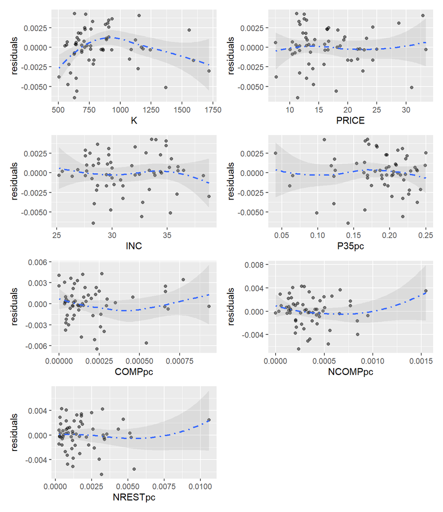

```r
plot(result, plots = "resid_pred", lines = "loess", nrobs = -1, custom = FALSE)
```

#### Appendix 2-2, G

We then removed the non-significant variables of COMPpc and NCOMPpc.

```r
result <- regress(
  CroqPainFix,
  rvar = "EARNpc",
  evar = c("K", "PRICE", "INC", "P35pc", "NRESTpc")
)
summary(result, sum_check = "vif")
```

```
## Linear regression (OLS)
## Data     : CroqPainFix
## Response variable    : EARNpc
## Explanatory variables: K, PRICE, INC, P35pc, NRESTpc
## Null hyp.: the effect of x on EARNpc is zero
## Alt. hyp.: the effect of x on EARNpc is not zero
##
##              coefficient std.error t.value p.value
##  (Intercept)      -0.017     0.004  -4.369  < .001 ***
##  K                 0.000     0.000   5.580  < .001 ***
##  PRICE            -0.000     0.000  -5.366  < .001 ***
##  INC               0.000     0.000   4.351  < .001 ***
##  P35pc             0.031     0.008   3.757  < .001 ***
##  NRESTpc           1.094     0.215   5.078  < .001 ***
##
## Signif. codes:  0 '***' 0.001 '**' 0.01 '*' 0.05 '.' 0.1 ' ' 1
##
## R-squared: 0.645,  Adjusted R-squared: 0.613
## F-statistic: 19.66 df(5,54), p.value < .001
## Nr obs: 60
##
## Variance Inflation Factors
##         K PRICE P35pc NRESTpc   INC
## VIF 1.740 1.595 1.257   1.232 1.114
## Rsq 0.425 0.373 0.204   0.188 0.102
```

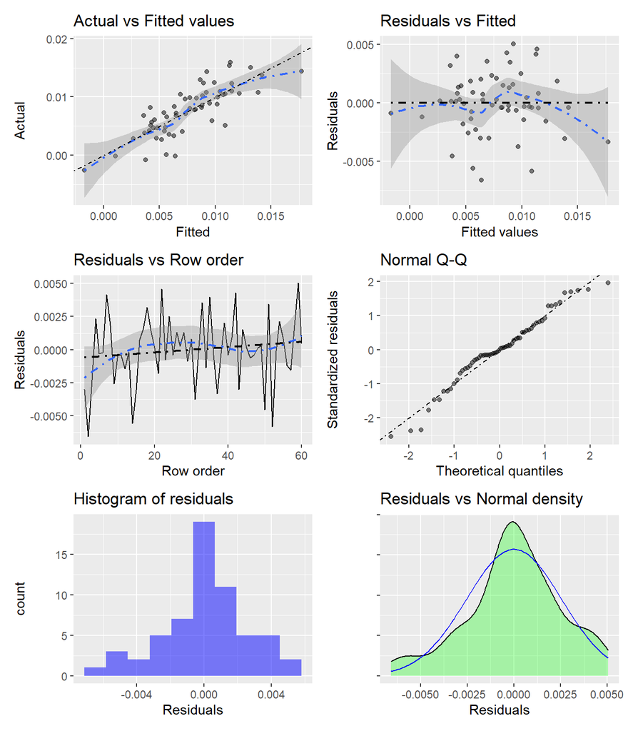

```r
plot(result, plots = "dashboard", lines = c("line", "loess"), custom = FALSE)
```

### Appendix 2-3: Validation by Testing

#### Appendix 2-3, A

We break up the dataset to validate the model

```r
CroqPainFix_50 <- CroqPainFix %>%
  filter(STOR <= 50)

CroqPainFix_10 <- CroqPainFix %>%
  filter(STOR > 50)
```

#### Appendix 2-3, B

Checking the model with the most recent 10 stores.

```r
result <- regress(
  CroqPainFix_50,
  rvar = "EARNpc",
  evar = c("K", "INC", "PRICE", "P35pc", "NRESTpc")
)
summary(result, sum_check = "vif")
```

```
## Linear regression (OLS)
## Data     : CroqPainFix_50
## Response variable    : EARNpc
## Explanatory variables: K, INC, PRICE, P35pc, NRESTpc
## Null hyp.: the effect of x on EARNpc is zero
## Alt. hyp.: the effect of x on EARNpc is not zero
##
##              coefficient std.error t.value p.value
##  (Intercept)      -0.020     0.004  -5.106  < .001 ***
##  K                 0.000     0.000   3.639  < .001 ***
##  INC               0.001     0.000   4.873  < .001 ***
##  PRICE            -0.000     0.000  -3.838  < .001 ***
##  P35pc             0.034     0.009   3.928  < .001 ***
##  NRESTpc           1.269     0.229   5.540  < .001 ***
##
## Signif. codes:  0 '***' 0.001 '**' 0.01 '*' 0.05 '.' 0.1 ' ' 1
##
## R-squared: 0.668,  Adjusted R-squared: 0.631
## F-statistic: 17.729 df(5,44), p.value < .001
## Nr obs: 50
##
## Variance Inflation Factors
##         K PRICE P35pc NRESTpc  INC
## VIF 2.255 1.863 1.423   1.385 1.25
## Rsq 0.557 0.463 0.297   0.278 0.20
```

```r
pred <- predict(result, pred_data = CroqPainFix_10)
print(pred, n = 10)
```

```
## Linear regression (OLS)
## Data                 : CroqPainFix_50
## Response variable    : EARNpc
## Explanatory variables: K, INC, PRICE, P35pc, NRESTpc
## Interval             : confidence
## Prediction dataset   : CroqPainFix_10
##
##         K    INC  PRICE P35pc NRESTpc Prediction   2.5% 97.5%   +/-
##   775.979 32.100 11.600 0.182   0.001      0.009  0.008 0.010 0.001
##   647.752 32.700 18.000 0.218   0.005      0.012  0.010 0.015 0.002
##   689.843 30.000 13.600 0.169   0.000      0.004  0.003 0.006 0.001
##   715.018 34.400 16.500 0.195   0.001      0.008  0.007 0.009 0.001
##   650.061 28.800 12.800 0.154   0.001      0.004  0.002 0.005 0.001
##   788.411 28.700 24.300 0.175   0.000      0.001 -0.000 0.003 0.002
##   781.951 33.400 13.300 0.243   0.003      0.012  0.011 0.014 0.002
##  1557.841 27.600 18.300 0.224   0.002      0.011  0.008 0.015 0.004
##   935.575 28.700 12.500 0.171   0.003      0.008  0.007 0.010 0.002
##   687.978 36.000 14.100 0.238   0.001      0.011  0.009 0.013 0.002
```

```r
CroqPainFix_10 <- store(CroqPainFix_10, pred, name = "pred_reg")
CroqPainFix_10 %>%
  select(STOR, EARNpc, pred_reg)
```

```
## # A tibble: 10 x 3
##     STOR    EARNpc pred_reg
##    <dbl>     <dbl>    <dbl>
##  1    51  0.0124    0.00853
##  2    52  0.00510   0.0122
##  3    53  0.00473   0.00435
##  4    54  0.00985   0.00814
##  5    55  0.00506   0.00370
##  6    56 -0.000135  0.00127
##  7    57  0.0106    0.0124
##  8    58  0.0150    0.0114
##  9    59  0.0143    0.00837
## 10    60  0.0109    0.0110
```

The predicted earning per capita is reasonably close to the actual earning per capita.

#### Appendix 2-3, C

We then checked the model’s ability to predict the performance ratio. We omit K since it is used in the calculation for PR.

```r
result <- regress(
  CroqPainFix_50,
  rvar = "PR",
  evar = c("INC", "PRICE", "P35pc", "NRESTpc")
)
summary(result, sum_check = "vif")
```

```
## Linear regression (OLS)
## Data     : CroqPainFix_50
## Response variable    : PR
## Explanatory variables: INC, PRICE, P35pc, NRESTpc
## Null hyp.: the effect of x on PR is zero
## Alt. hyp.: the effect of x on PR is not zero
##
##              coefficient std.error t.value p.value
##  (Intercept)      -0.419     0.108  -3.887  < .001 ***
##  INC               0.013     0.003   4.538  < .001 ***
##  PRICE            -0.006     0.002  -3.849  < .001 ***
##  P35pc             1.359     0.224   6.070  < .001 ***
##  NRESTpc          17.651     6.055   2.915   0.006 **
##
## Signif. codes:  0 '***' 0.001 '**' 0.01 '*' 0.05 '.' 0.1 ' ' 1
##
## R-squared: 0.649,  Adjusted R-squared: 0.618
## F-statistic: 20.832 df(4,45), p.value < .001
## Nr obs: 50
##
## Variance Inflation Factors
##     NRESTpc P35pc PRICE   INC
## VIF   1.334 1.307 1.037 1.034
## Rsq   0.250 0.235 0.035 0.033
```

```r
pred <- predict(result, pred_data = CroqPainFix_10)
pred2 <- predict(result, pred_data = CroqPainFix_10, conf_lev = 0.99)
print(pred,n = 10)
```

```
## Linear regression (OLS)
## Data                 : CroqPainFix_50
## Response variable    : PR
## Explanatory variables: INC, PRICE, P35pc, NRESTpc
## Interval             : confidence
## Prediction dataset   : CroqPainFix_10
##
##     INC  PRICE P35pc NRESTpc Prediction  2.5% 97.5%   +/-
##  32.100 11.600 0.182   0.001      0.211 0.184 0.237 0.026
##  32.700 18.000 0.218   0.005      0.298 0.239 0.357 0.059
##  30.000 13.600 0.169   0.000      0.135 0.103 0.167 0.032
##  34.400 16.500 0.195   0.001      0.225 0.199 0.252 0.027
##  28.800 12.800 0.154   0.001      0.112 0.077 0.147 0.035
##  28.700 24.300 0.175   0.000      0.060 0.022 0.098 0.038
##  33.400 13.300 0.243   0.003      0.321 0.281 0.362 0.041
##  27.600 18.300 0.224   0.002      0.172 0.136 0.208 0.036
##  28.700 12.500 0.171   0.003      0.163 0.135 0.191 0.028
##  36.000 14.100 0.238   0.001      0.318 0.279 0.358 0.040
```

```r
print(pred2,n = 10)
```

```
## Linear regression (OLS)
## Data                 : CroqPainFix_50
## Response variable    : PR
## Explanatory variables: INC, PRICE, P35pc, NRESTpc
## Interval             : confidence
## Prediction dataset   : CroqPainFix_10
##
##     INC  PRICE P35pc NRESTpc Prediction  0.5% 99.5%   +/-
##  32.100 11.600 0.182   0.001      0.211 0.176 0.246 0.035
##  32.700 18.000 0.218   0.005      0.298 0.220 0.377 0.079
##  30.000 13.600 0.169   0.000      0.135 0.093 0.178 0.043
##  34.400 16.500 0.195   0.001      0.225 0.190 0.261 0.036
##  28.800 12.800 0.154   0.001      0.112 0.065 0.159 0.047
##  28.700 24.300 0.175   0.000      0.060 0.010 0.111 0.051
##  33.400 13.300 0.243   0.003      0.321 0.267 0.375 0.054
##  27.600 18.300 0.224   0.002      0.172 0.124 0.220 0.048
##  28.700 12.500 0.171   0.003      0.163 0.126 0.200 0.037
##  36.000 14.100 0.238   0.001      0.318 0.265 0.371 0.053
```

```r
CroqPainFix_10 <- store(CroqPainFix_10, pred, name = "pred_reg_PR95")
CroqPainFix_10 <- store(CroqPainFix_10, pred2, name = "pred_reg_PR99")
CroqPainFix_10 %>%
  select(STOR, PR, pred_reg_PR95, pred_reg_PR99)
```

```
## # A tibble: 10 x 4
##     STOR       PR pred_reg_PR95 pred_reg_PR99
##    <dbl>    <dbl>         <dbl>         <dbl>
##  1    51  0.279          0.211         0.211
##  2    52  0.101          0.298         0.298
##  3    53  0.0980         0.135         0.135
##  4    54  0.179          0.225         0.225
##  5    55  0.128          0.112         0.112
##  6    56 -0.00365        0.0604        0.0604
##  7    57  0.317          0.321         0.321
##  8    58  0.220          0.172         0.172
##  9    59  0.206          0.163         0.163
## 10    60  0.403          0.318         0.318
```

These are also reasonable predictors. However, we do note that Store 52 is now predicted to make the ratio requirement and Store 51 does not. However, the overall model is still not bad, and Store 57 and Store 60 are still making the ratio requirement.

### Appendix 2-3: Prediction

Add variables to the new dataseset

```r
CroqPain_new <- CroqPain_new %>%
  mutate(P15pc = P15/total,
         P25pc = P25/total,
         P35pc = P35/total,
         P45pc = P45/total,
         P55pc = P55/total,
         COMPpc = COMP/total,
         NCOMPpc = NCOMP/total,
         NRESTpc = NREST/total)
```

#### Appendix 2-3, A

We then used this model to predict the earnings for the potential new stores.

```r
result <- regress(
  CroqPainFix,
  rvar = "EARNpc",
  evar = c("K", "INC", "PRICE", "P35pc", "NRESTpc")
)
summary(result)
```

```
## Linear regression (OLS)
## Data     : CroqPainFix
## Response variable    : EARNpc
## Explanatory variables: K, INC, PRICE, P35pc, NRESTpc
## Null hyp.: the effect of x on EARNpc is zero
## Alt. hyp.: the effect of x on EARNpc is not zero
##
##              coefficient std.error t.value p.value
##  (Intercept)      -0.017     0.004  -4.369  < .001 ***
##  K                 0.000     0.000   5.580  < .001 ***
##  INC               0.000     0.000   4.351  < .001 ***
##  PRICE            -0.000     0.000  -5.366  < .001 ***
##  P35pc             0.031     0.008   3.757  < .001 ***
##  NRESTpc           1.094     0.215   5.078  < .001 ***
##
## Signif. codes:  0 '***' 0.001 '**' 0.01 '*' 0.05 '.' 0.1 ' ' 1
##
## R-squared: 0.645,  Adjusted R-squared: 0.613
## F-statistic: 19.66 df(5,54), p.value < .001
## Nr obs: 60
```

```r
pred <- predict(result, pred_data = CroqPain_new)
print(pred, n = 10)
```

```
## Linear regression (OLS)
## Data                 : CroqPainFix
## Response variable    : EARNpc
## Explanatory variables: K, INC, PRICE, P35pc, NRESTpc
## Interval             : confidence
## Prediction dataset   : CroqPain_new
##
##         K    INC  PRICE P35pc NRESTpc Prediction   2.5% 97.5%   +/-
##   660.140 38.400 21.700 0.064   0.003      0.005  0.001 0.008 0.003
##   733.000 31.300 12.500 0.191   0.002      0.009  0.008 0.009 0.001
##  1050.349 29.000 21.700 0.196   0.001      0.006  0.005 0.007 0.001
##   836.000 37.000 12.500 0.226   0.005      0.017  0.015 0.020 0.002
##   783.616 30.000 18.000 0.143   0.011      0.015  0.011 0.018 0.004
##   924.808 23.000 12.000 0.181   0.003      0.008  0.005 0.010 0.002
##  1089.576 25.200 33.400 0.169   0.000     -0.002 -0.004 0.001 0.003
##   737.662 30.100  9.000 0.094   0.001      0.006  0.003 0.008 0.002
##   584.000 28.600 13.400 0.242   0.001      0.006  0.005 0.008 0.001
##   681.000 34.900 15.400 0.079   0.004      0.008  0.006 0.010 0.002
```

```r
CroqPain_new <- store(CroqPain_new, pred, name = "pred_reg_EARNpc")
CroqPain_new %>%
  select(STOR, pred_reg_EARNpc)
```

```
##            STOR pred_reg_EARNpc
## 1        Calais     0.004573191
## 2    Montchanin     0.008521517
## 3      Aubusson     0.006060666
## 4      Toulouse     0.017252685
## 5         Torcy     0.014511312
## 6  Marseilles-1     0.007652490
## 7  Marseilles-2    -0.001700159
## 8      Clermont     0.005549628
## 9   Montpellier     0.006415517
## 10        Dijon     0.007756595
```

#### Appendix 2-3, B

```r
result <- regress(
  CroqPainFix,
  rvar = "PR",
  evar = c("INC", "PRICE", "P35pc", "NRESTpc")
)
summary(result)
```

```
## Linear regression (OLS)
## Data     : CroqPainFix
## Response variable    : PR
## Explanatory variables: INC, PRICE, P35pc, NRESTpc
## Null hyp.: the effect of x on PR is zero
## Alt. hyp.: the effect of x on PR is not zero
##
##              coefficient std.error t.value p.value
##  (Intercept)      -0.376     0.100  -3.752  < .001 ***
##  INC               0.013     0.003   4.619  < .001 ***
##  PRICE            -0.007     0.002  -4.452  < .001 ***
##  P35pc             1.283     0.211   6.070  < .001 ***
##  NRESTpc          13.251     5.582   2.374   0.021 *
##
## Signif. codes:  0 '***' 0.001 '**' 0.01 '*' 0.05 '.' 0.1 ' ' 1
##
## R-squared: 0.632,  Adjusted R-squared: 0.605
## F-statistic: 23.591 df(4,55), p.value < .001
## Nr obs: 60
```

```r
pred <- predict(result, pred_data = CroqPain_new)
print(pred, n = 10)
```

```
## Linear regression (OLS)
## Data                 : CroqPainFix
## Response variable    : PR
## Explanatory variables: INC, PRICE, P35pc, NRESTpc
## Interval             : confidence
## Prediction dataset   : CroqPain_new
##
##     INC  PRICE P35pc NRESTpc Prediction   2.5% 97.5%   +/-
##  38.400 21.700 0.064   0.003      0.091  0.021 0.161 0.070
##  31.300 12.500 0.191   0.002      0.215  0.193 0.237 0.022
##  29.000 21.700 0.196   0.001      0.117  0.088 0.146 0.029
##  37.000 12.500 0.226   0.005      0.382  0.319 0.444 0.062
##  30.000 18.000 0.143   0.011      0.217  0.120 0.314 0.097
##  23.000 12.000 0.181   0.003      0.115  0.063 0.167 0.052
##  25.200 33.400 0.169   0.000     -0.057 -0.123 0.009 0.066
##  30.100  9.000 0.094   0.001      0.089  0.035 0.142 0.054
##  28.600 13.400 0.242   0.001      0.232  0.197 0.267 0.035
##  34.900 15.400 0.079   0.004      0.129  0.076 0.183 0.054
```

#### Appendix 2-3, C

```r
CroqPain_new <- store(CroqPain_new, pred, name = "pred_reg_PR")
CroqPain_new %>%
  select(STOR, pred_reg_PR)
```

```
##            STOR pred_reg_PR
## 1        Calais  0.09130488
## 2    Montchanin  0.21504445
## 3      Aubusson  0.11689051
## 4      Toulouse  0.38152405
## 5         Torcy  0.21705915
## 6  Marseilles-1  0.11499958
## 7  Marseilles-2 -0.05729830
## 8      Clermont  0.08865138
## 9   Montpellier  0.23176096
## 10        Dijon  0.12944325
```

Based on these prediced performance ratios, we recommend opening the Toulouse store. We tentatively also recommend Montchanin and Montpellier if the company is willing to take on risk.